# Social Media Network Study

Christine Grayson

11/5/2021

# Introduction

This is a presentation to describe a shiny app created for the final project of the Coursera course “Developing Data Products”

Currently I work on a research project to study the spread of information on social media, so I had an idea to create an app that would help me with my work.

The idea of this interactive graph is to be able to peer into the event network at user defined time ranges to see what type of connections there are.

This app is intended to answer such questions as “are peaks in activity due to many users sending to many other users or are there just a few super users or bots sending to many users?”

# Data

One of the hardest problems in completing this project was producing the data.

It was not possible to use data from the project as it is restricted, so synthetic data had to be created.

It was possible to get edge data quite easily, but data that included date information seemed hard to find.

Eventually it was decided to use an open source edge list from [here](http://datasets.syr.edu/datasets/Flickr.html) and apply dates by hand using excel. The head of the data is given below using the head command.

```
                date parent  child
1 2020-06-02 0:00:00 100000 100032
2 2020-06-02 0:20:00 100000  14106
3 2020-06-02 0:40:00 100000  14133
4 2020-06-02 1:00:00 100000 157817
5 2020-06-02 1:20:00 100000  15856
6 2020-06-02 1:40:00 100000   1610
```

# How the App Works

A plotly histogram of events over time is shown on the left. On the right is the network graph initially depicting all the events.

The user can then select date ranges using the slider above the histogram.

The events in that time range are used to create a network graph.

The user can interact with the network graphic, the mouse scroll can be used zoom in and out, left click to pan.

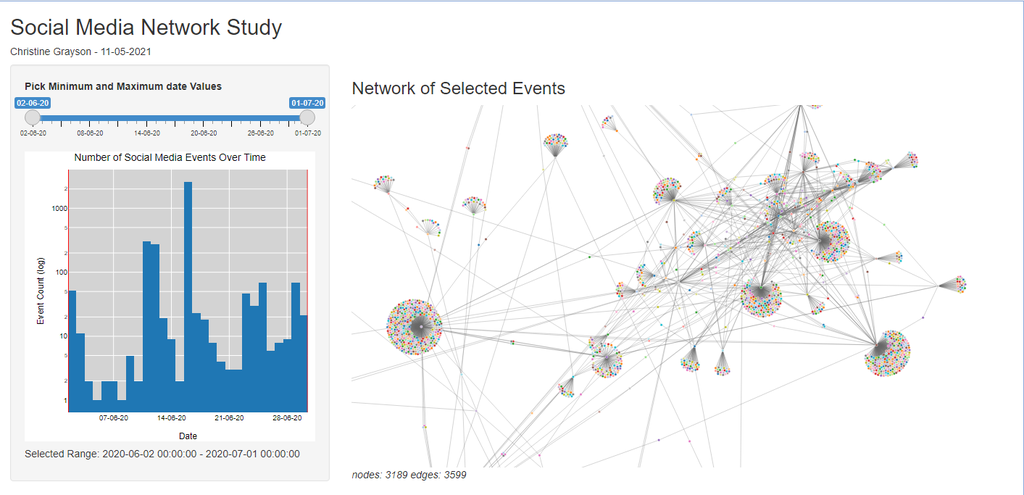

# Links to Information

The following are the links to information on line

[The Source of Data](http://datasets.syr.edu/datasets/Flickr.html)

[The Project Source Code on Github](https://github.com/graysonch/DevelopingDataProducts/tree/master/Week4FinalProject)

This Presentation on Github

[The Theme Used for the Presentation](https://bootswatch.com/darkly/)

[Link to the Deployed Shiny App](https://graysonch.shinyapps.io/week4finalproject/)